# Let's talk about DOGS and how they perform on Twitter!

*by: Dorothy Kunth*

## Dogs on Twitter

Dogs are also social media superstars! If we try to search "dog" in the people category on Twitter, a bunch of Twitter users will appear like below.

[figure not shown]

Dogs on Twitter are not just about bragging adorable dogs, some are related to guide dogs (like the one providing life-changing support, skills and dogs to people living with sight loss), some are about dog welfare charities, and some are professional dog raters.

## WeRateDogs®

The top on search is Twitter user @dog_rates also known as WeRateDogs®. According to their Twitter Bio, they are *'Your Only Source For Professional Dog Ratings.'* WeRateDogs® joined Twitter in November 2015 and has 9.2M followers and 15.3K Tweets as of today. They are averaging about 6 Tweets per day. The account was started in 2015 by college student Matt Nelson, and has received international media attention for its popularity.

[figure not shown]

WeRateDog® has a *Dog Submission Portal* [WeRateDogs®](https://links.weratedogs.com/) where followers can submit photos (or videos) of their dogs with some 'tell me something about your dog'. WeRateDogs® then tweets selected photos with rating and humorous comment. According to [WeRateDog® Wikipedia](https://en.wikipedia.org/wiki/WeRateDogs), they receive 800 to 1,000 submissions daily.

[figure not shown]

## WeRateDogs® Tweets

WeRateDogs® are committed to humorously reviewing pictures of dogs doing adorable poses, often giving them hilarious rating score. Dogs are rated on a scale of one to ten, but are invariably given ratings in excess of the maximum, such as "14/10".

[figure not shown]

And check this out - with rating of 144/120 - because they are 12 dogs!

[figure not shown]

Aside from amusing comments and crazy ratings, some tweets state the name, the breed and the stage of dogs. Yes, dog stage. There is a so-called Dogtionary [WeRateDogs® book on Amazon](https://www.amazon.com/WeRateDogs-Most-Hilarious-Adorable-Youve/dp/1510717145) that explains the various stages of dog: doggo, pupper, puppo, and floof(er).

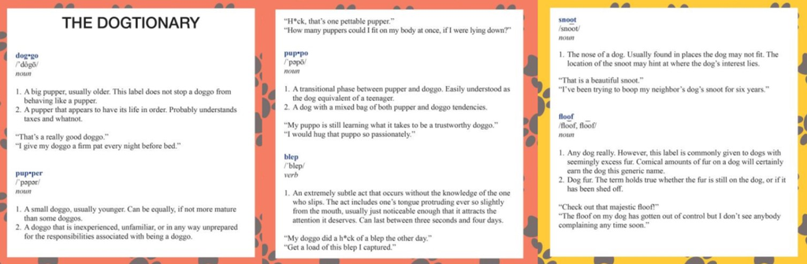

## Insights

We have gathered WeRateDogs® twitter archive data from their first ever tweet on November 15, 2015 until July 2017. We pre-processed the data and turned it into interesting insights.

## Twitter for iPhone is the utility mostly used by WeRateDogs® for posting tweets.

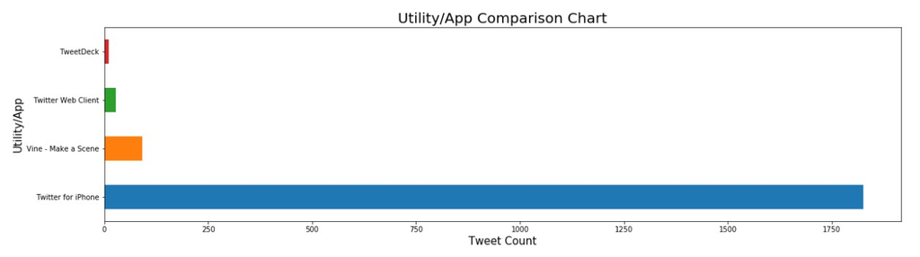

Pretty sure WeRateDogs® is an iPhone user. Nelson uses Twitter for iPhone almost all the time as opposed to Vine, Web or TweetDeck.

## Is there a relationship between the Likes and Retweets associated with dog breeds?

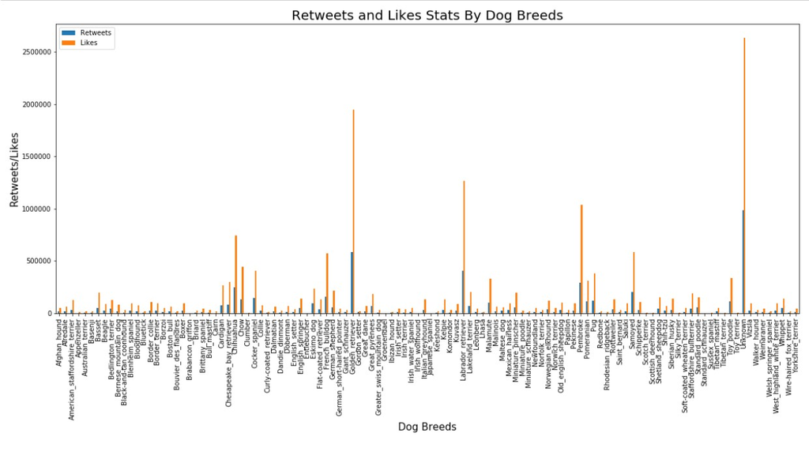

Setting aside the 'unknown' which refers to those dogs whose breeds are not mentioned in the tweets, **Golden Retriever** took the tops spot with 586,657 Retweets and 1,943,782 Likes. Followed by **Labrador Retriever** with 405,404 Retweets and 1,265,355 Likes. **Pembroke** comes third with 291,771 Retweets and 1,038,797 Likes.

## What about the relationship between Likes and Retweets associated with dog stages?

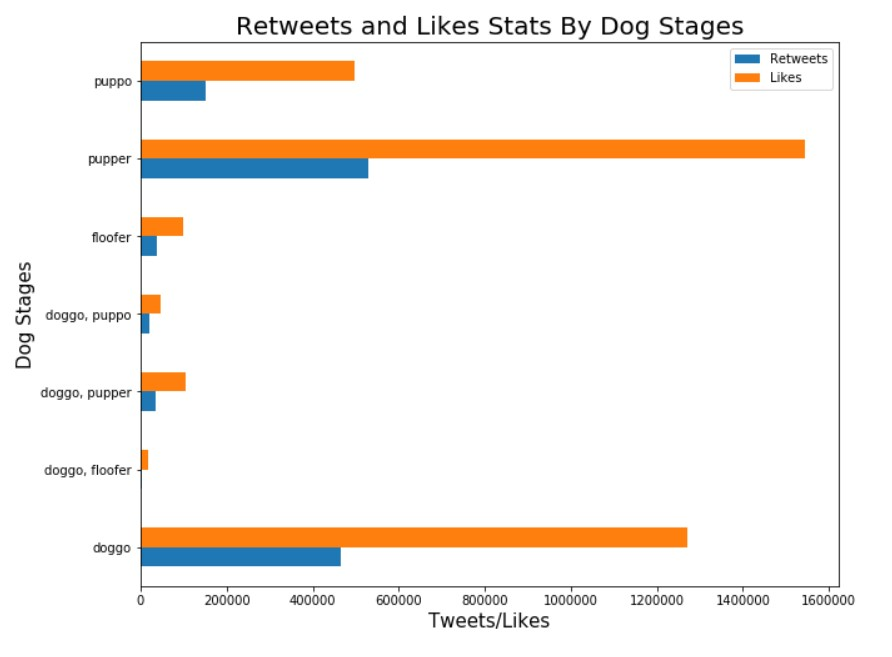

In this bar graph, pupper has the longest bars with total Retweets of 528,234 and total Likes of 1,543,210, followed by doggo which has total Retweets of 466,193 and total likes of 1,272,012.

What's a pupper? a doggo? According to the Dogtionary, *a pupper is a small doggo, usually younger, can be equally , if not more mature than some doggos!* While *a doggo is a big pupper , usually older, and this label does not stop a doggo from behaving like a pupper!*

## Here's the Top 20 Most Popular Names.

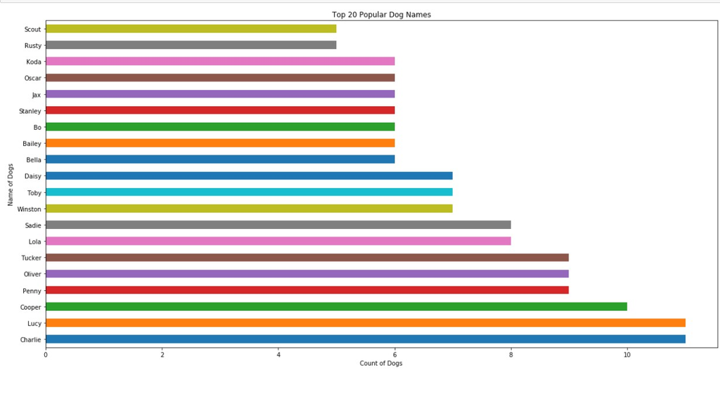

**Charlie** and **Lucy** share the top spot. The second popular is **Cooper**. Then **Penny**, **Oliver** and **Tucker** share the third spot. Cool names!

## Most Retweeted Tweet has 79515 Retweets!

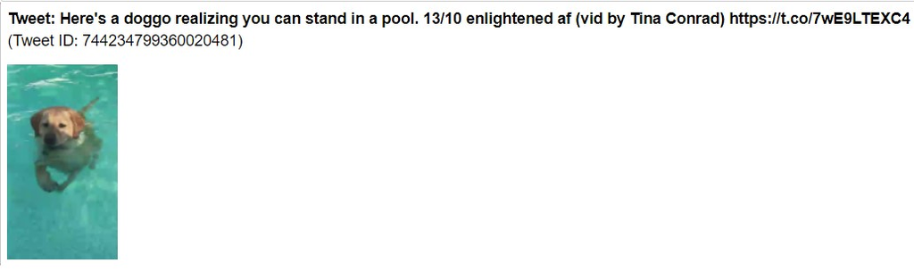

## Most Liked Tweet has 132810 Likes!

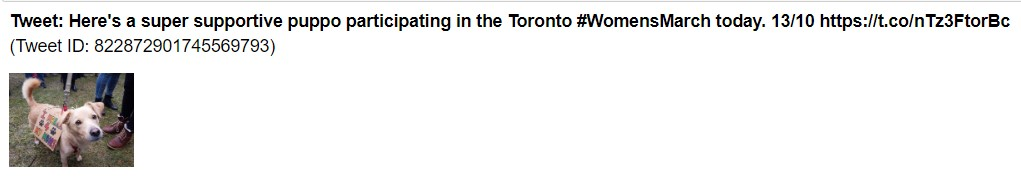

## Average ratings per dog stage are almost equally distributed.

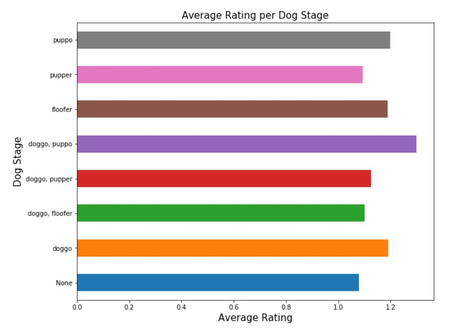

Multiple dog stage doggo,puppo got the highest average rating of 1.3. Here's the doggo, puppo or puppo, doggo.

[figure not shown]

## Top 20 Dog Breeds with the Highest Average Ratings

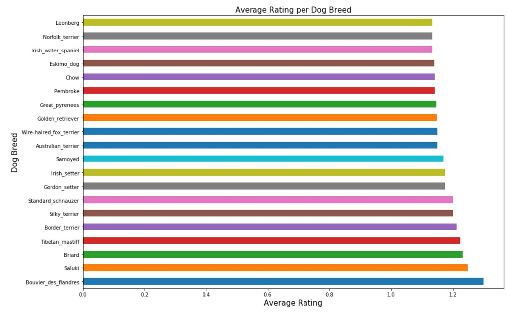

Dog breed Bouvier_des_flandres got the top spot with average rating of 1.3. Here he is.

[figure not shown]

## Dog Stages Pie Chart

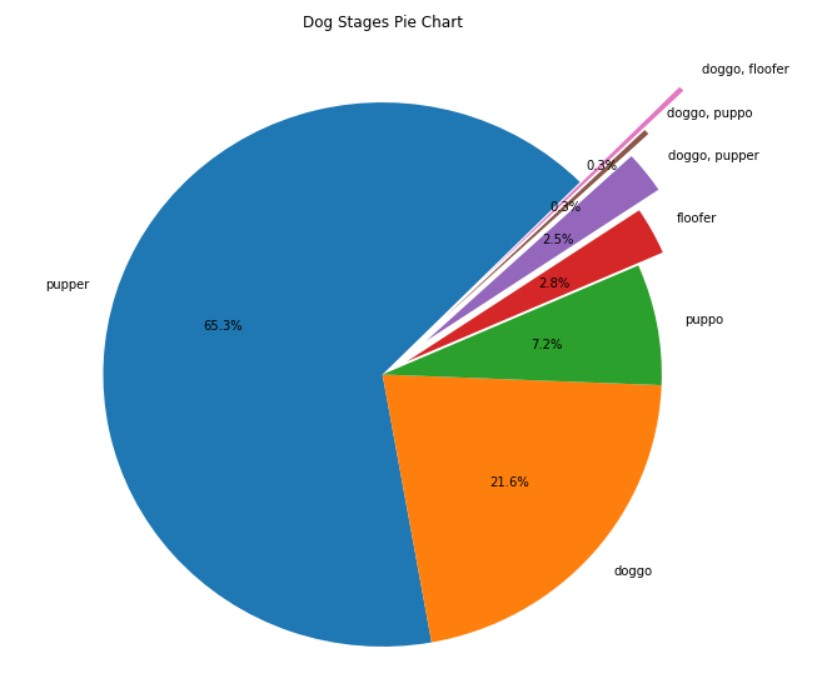

Those dogs without dog stages were excluded for the purpose of this insight. For those dogs that have dog stages, pupper has the biggest slice of the pie and so the most common among them. Followed by doggo, then puppo.

## Retweets and Likes Correlation per Rating

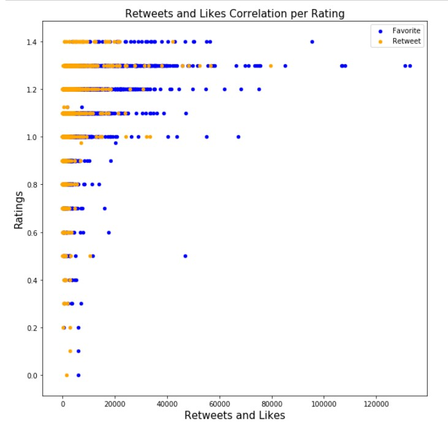

It appears that the higher the rating of the dogs, the more Likes and Retweets they get.